# Phase Adjustment Task - JB_RS

Published

05 February, 2024

# 1 Summary Statistics

25 individuals successfully provided data through the app and prolific system. Similarity scores were calculated using the first 17 trials for each individual. Summary statistics for similarity scores and other metrics are presented below.

|  | Overall (N=25) |
| --- | --- |
| **Similarity** |  |
| Mean (SD) | 0.38 (0.16) |
| Range | 0.09 - 0.72 |
| **Mean confidence score** |  |
| Mean (SD) | 4.89 (1.80) |
| Range | 1.18 - 7.82 |
| **Mean heart rate (bpm)** |  |
| Mean (SD) | 78.76 (6.87) |
| Range | 63.47 - 92.86 |
| **SDNN** |  |
| Mean (SD) | 154.59 (100.39) |
| Range | 49.45 - 375.94 |
| **RMSSD** |  |
| Mean (SD) | 128.52 (76.84) |
| Range | 42.63 - 261.65 |
| **PNN50** |  |
| Mean (SD) | 49.84 (18.35) |
| Range | 19.23 - 77.08 |
| **Time spent on each trial (sec)** |  |
| Mean (SD) | 22.25 (9.48) |
| Range | 8.14 - 41.43 |
| **Mean engagement trials (sec)** |  |
| Mean (SD) | 27.91 (12.04) |
| Range | 9.29 - 52.53 |
| **Similarity Difference - Confidence Correlation** |  |
| Mean (SD) | 0.00 (0.25) |
| Range | -0.58 - 0.62 |

# 2 Were participant responses non-random?

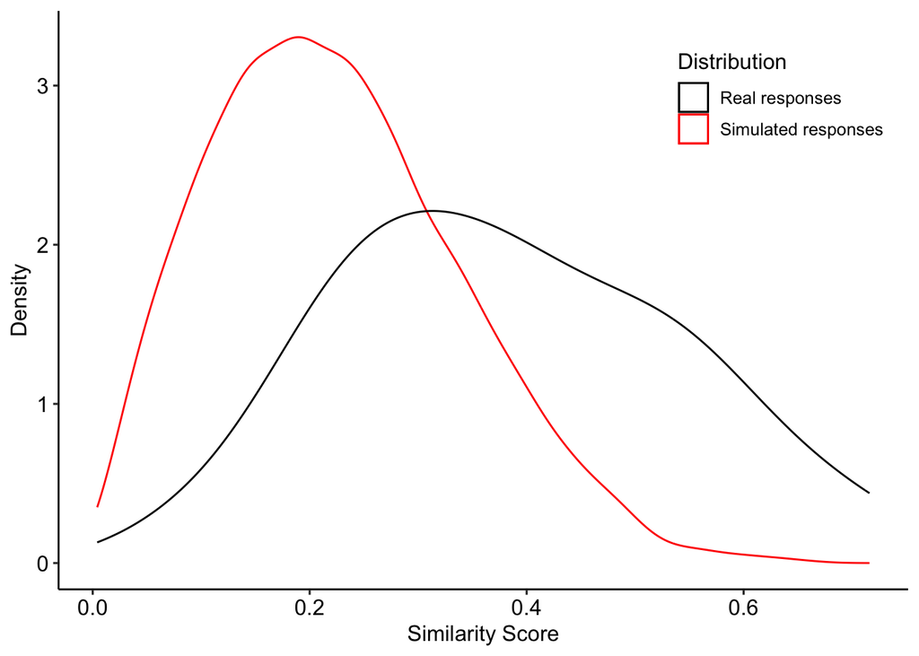

Probability density function of data from simulated participants responding at random (red line) and real participants’ data (black line).

| statistic | p.value | method | alternative |
| --- | --- | --- | --- |
| 99106 | 0.0000004 | Wilcoxon rank sum test with continuity correction | two.sided |

By comparing the responses from the participants to a randomly generated distribution (**5000** iterations) we can see if the participants were answering randomly. A wilcox test indicates that the distribution of participants responses is different to the randomly generated distribution **(Z= -5.059, *p*<.001, *r* = -0.071)**. This suggests participants were not responding randomly.

# 3 Classifying participants as interoceptive or non-interoceptive

In order to classify participants as either interoceptive or non-interoceptive, a gaussian mixture model with 2 mixtures was applied to the similarity values following the assumption that the population is made of two subpopulations; interoceptive and non-interoceptive participants. Briefly, a Z-score for each participant was calculated for the interoceptive and non-interoceptive distributions separately, and these Z-scores were used to calculate the probability of an individual being interoceptive or non-interoceptive. The estimated probability distributions, along with the distribution of real responses can be seen below.

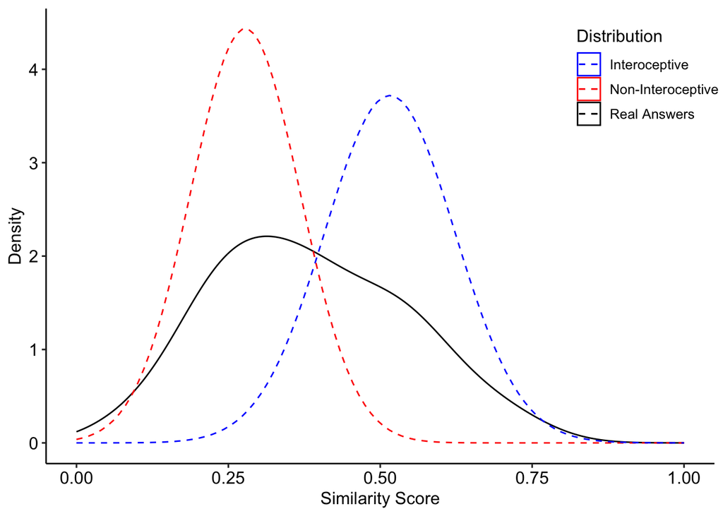

Probability density function of real participants’ data (black line), estimated distribution of non-interoceptive participants (red line) and interoceptive participants (blue line).

[output not shown]

Comparing the probabilities of a participant being Interoceptive or Non-Interoceptive allows a Bayes Factor (BF) to be calculated as the ratio of an individual belonging to one of the two distributions, over the probability of belonging to the other distribution. This allows each participant to be classified as being Interoceptive, Non-Interoceptive, or Unknown (Unclassifed). This classification was carried out using three BF thresholds, >3, >10 and >30.

|  | Overall (N=25) |
| --- | --- |
| **BF > 3** |  |
| Interoceptive participants | 10 (40.0%) |
| Non interoceptive participants | 11 (44.0%) |
| Unknown | 4 (16.0%) |
| **BF > 10** |  |
| Interoceptive participants | 8 (32.0%) |
| Non interoceptive participants | 10 (40.0%) |
| Unknown | 7 (28.0%) |
| **BF > 30** |  |
| Interoceptive participants | 7 (28.0%) |
| Non interoceptive participants | 9 (36.0%) |
| Unknown | 9 (36.0%) |

At a BF threshold of >3 **10 (40.0%)** participants were classified as interoceptive. Previous studies using multi-delay heartbeat detection tasks estimate that approximately 1/3 of healthy participants are interoceptive.

# 4 Correlation between similarity scores and heart rate variability

## 4.1 All participants

| Var. 1 | Var. 2 | r | p-value | Type |
| --- | --- | --- | --- | --- |
| similarity | Mean Heart Rate | 0.22 | 0.293 | Pearson |
| similarity | Mean Heart Rate | 0.19 | 0.353 | Spearman |
| similarity | SDNN | -0.25 | 0.232 | Pearson |
| similarity | SDNN | -0.22 | 0.286 | Spearman |
| similarity | RMSSD | -0.03 | 0.905 | Pearson |
| similarity | RMSSD | 0.00 | 0.984 | Spearman |
| similarity | PNN50 | 0.25 | 0.233 | Pearson |
| similarity | PNN50 | 0.19 | 0.369 | Spearman |

## 4.2 Interoceptive Participants (BF>3)

| Var. 1 | Var. 2 | r | p-value | Type |
| --- | --- | --- | --- | --- |
| similarity | Mean Heart Rate | 0.21 | 0.554 | Pearson |
| similarity | Mean Heart Rate | 0.14 | 0.707 | Spearman |
| similarity | SDNN | 0.24 | 0.497 | Pearson |
| similarity | SDNN | 0.47 | 0.178 | Spearman |
| similarity | RMSSD | 0.55 | 0.098 | Pearson |
| similarity | RMSSD | 0.50 | 0.143 | Spearman |
| similarity | PNN50 | 0.74 | 0.015 | Pearson |
| similarity | PNN50 | 0.76 | 0.016 | Spearman |

## 4.3 Non-Interoceptive Participants (BF>3)

| Var. 1 | Var. 2 | r | p-value | Type |
| --- | --- | --- | --- | --- |
| similarity | Mean Heart Rate | 0.18 | 0.601 | Pearson |
| similarity | Mean Heart Rate | 0.25 | 0.451 | Spearman |
| similarity | SDNN | -0.29 | 0.393 | Pearson |
| similarity | SDNN | -0.30 | 0.371 | Spearman |
| similarity | RMSSD | -0.24 | 0.475 | Pearson |
| similarity | RMSSD | -0.16 | 0.634 | Spearman |
| similarity | PNN50 | -0.10 | 0.763 | Pearson |
| similarity | PNN50 | -0.10 | 0.776 | Spearman |

# 5 Correlation between Similarity scores and engagement metrics

## 5.1 All participants

| Var. 1 | Var. 2 | r | p-value | Type |
| --- | --- | --- | --- | --- |
| Similarity | Mean time taken on trials | 0.31 | 0.130 | Pearson |
| Similarity | Mean time taken on trials | 0.23 | 0.272 | Spearman |
| Similarity | Mean engagement trials | 0.34 | 0.101 | Pearson |
| Similarity | Mean engagement trials | 0.26 | 0.206 | Spearman |

## 5.2 Interoceptive Participants (BF>3)

| Var. 1 | Var. 2 | r | p-value | Type |
| --- | --- | --- | --- | --- |
| Similarity | Mean time taken on trials | 0.59 | 0.074 | Pearson |
| Similarity | Mean time taken on trials | 0.56 | 0.096 | Spearman |
| Similarity | Mean engagement trials | 0.63 | 0.051 | Pearson |
| Similarity | Mean engagement trials | 0.62 | 0.060 | Spearman |

## 5.3 Non-Interoceptive Participants (BF>3)

| Var. 1 | Var. 2 | r | p-value | Type |
| --- | --- | --- | --- | --- |
| Similarity | Mean time taken on trials | 0.07 | 0.846 | Pearson |
| Similarity | Mean time taken on trials | 0.00 | 1.000 | Spearman |
| Similarity | Mean engagement trials | 0.06 | 0.864 | Pearson |
| Similarity | Mean engagement trials | -0.04 | 0.924 | Spearman |

# 6 Differences in HRV / engagement / confidence between interoceptive / non-interoceptive participants (BF>3)

|  | Interoceptive participants (N=10) | Non interoceptive participants (N=11) | Unknown (N=4) | Total (N=25) | p value |
| --- | --- | --- | --- | --- | --- |
| **Similarity** |  |  |  |  | < 0.001 |
| Mean (SD) | 0.54 (0.09) | 0.24 (0.07) | 0.38 (0.03) | 0.38 (0.16) |  |
| Range | 0.42 - 0.72 | 0.09 - 0.34 | 0.36 - 0.41 | 0.09 - 0.72 |  |
| **Mean confidence score** |  |  |  |  | 0.354 |
| Mean (SD) | 5.48 (1.59) | 4.32 (1.94) | 4.97 (1.89) | 4.89 (1.80) |  |
| Range | 1.76 - 7.82 | 1.18 - 6.71 | 2.88 - 6.82 | 1.18 - 7.82 |  |
| **Mean heart rate** |  |  |  |  | 0.685 |
| Mean (SD) | 80.02 (6.30) | 77.39 (7.77) | 79.41 (6.66) | 78.76 (6.87) |  |
| Range | 72.79 - 92.86 | 63.47 - 89.74 | 71.44 - 87.37 | 63.47 - 92.86 |  |
| **SDNN** |  |  |  |  | 0.247 |
| Mean (SD) | 134.25 (96.23) | 191.23 (107.03) | 104.65 (70.92) | 154.59 (100.39) |  |
| Range | 49.45 - 375.94 | 66.22 - 333.92 | 57.27 - 210.04 | 49.45 - 375.94 |  |
| **RMSSD** |  |  |  |  | 0.740 |
| Mean (SD) | 125.82 (70.37) | 139.80 (84.75) | 104.28 (84.61) | 128.52 (76.84) |  |
| Range | 47.23 - 239.30 | 42.63 - 261.65 | 57.58 - 230.84 | 42.63 - 261.65 |  |
| **PNN50** |  |  |  |  | 0.836 |
| Mean (SD) | 52.50 (19.06) | 47.52 (19.97) | 49.56 (15.14) | 49.84 (18.35) |  |
| Range | 25.71 - 74.40 | 19.23 - 77.08 | 40.71 - 72.22 | 19.23 - 77.08 |  |
| **Time spent on each trial** |  |  |  |  | 0.449 |
| Mean (SD) | 23.23 (10.76) | 19.79 (8.03) | 26.59 (10.29) | 22.25 (9.48) |  |
| Range | 8.14 - 40.03 | 8.32 - 35.44 | 19.08 - 41.43 | 8.14 - 41.43 |  |
| **Mean engagement trials** |  |  |  |  | 0.347 |
| Mean (SD) | 29.42 (12.90) | 24.28 (10.94) | 34.07 (12.44) | 27.91 (12.04) |  |
| Range | 9.94 - 50.23 | 9.29 - 44.35 | 25.94 - 52.53 | 9.29 - 52.53 |  |

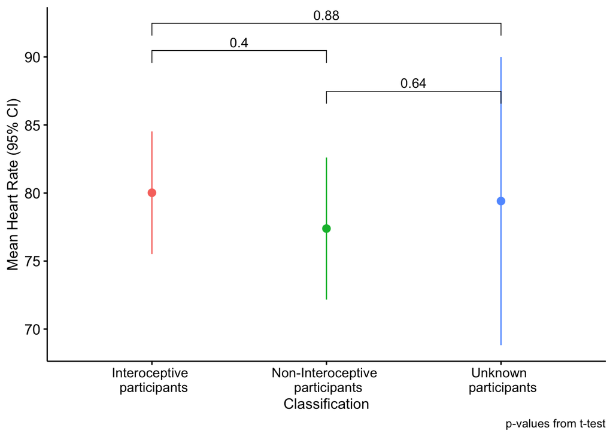

Difference in mean heart rate between participants classified as interoceptive, non-interoceptive or unknown.